# Analysis Speech

Tom Offrede

2022-09-15

## Conditions:

**GA: Gaze Aversion; the robot produced gaze aversion. Experimental condition.** **NG: No Gaze aversion; the robot stared constantly at the human. Control condition.**

# Between-Turn Gap Duration

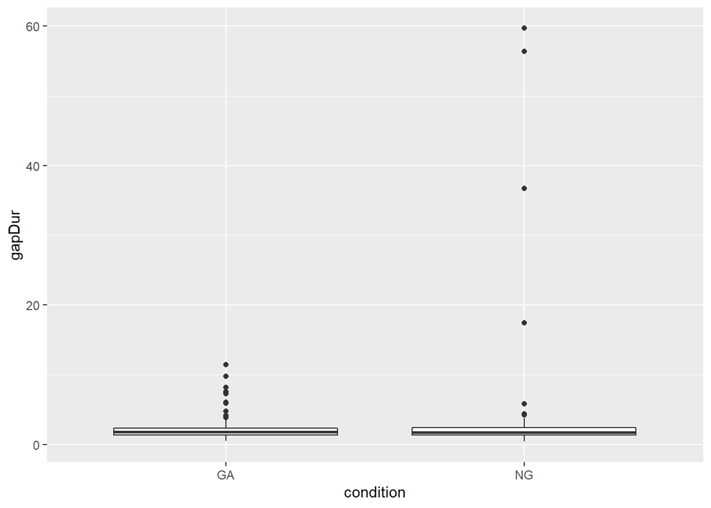

```r
ggplot(dac, aes(condition, gapDur))+
  geom_boxplot()
```

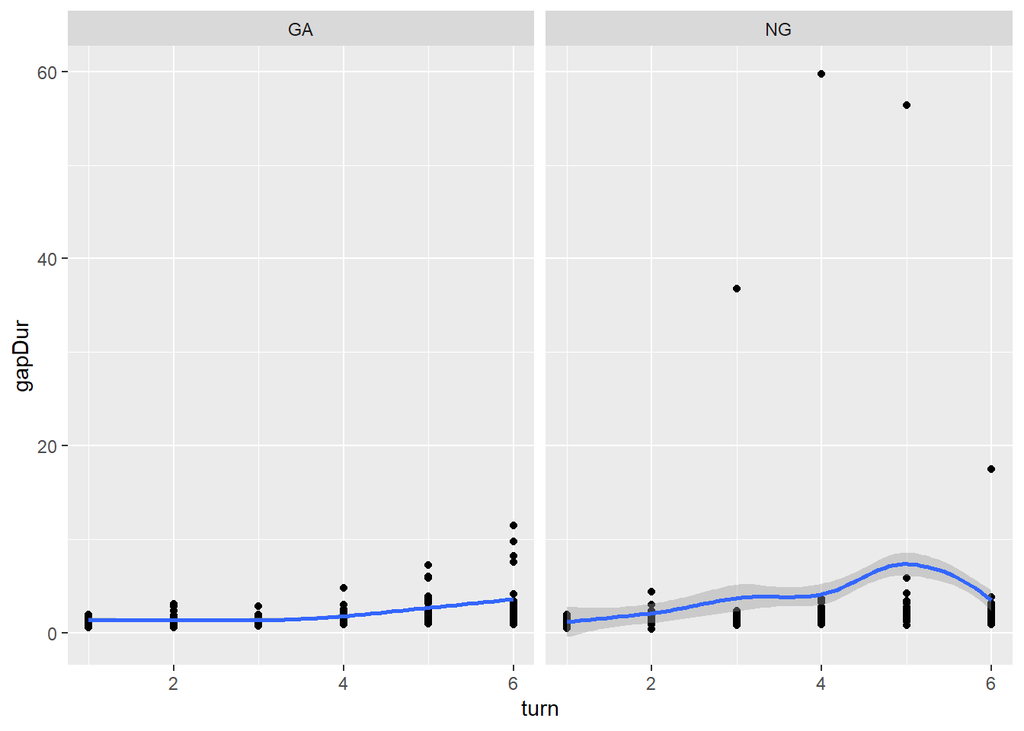

```r
ggplot(dac, aes(turn, gapDur))+
  geom_point()+
  facet_wrap(~condition)+
  geom_smooth(method="loess")
```

- There is a `turn` effect: longer gaps throughout the interaction. This model was better than the one using `intimacy` values
- There is **no `condition` effect**

```r
dac$condition <- relevel(dac$condition, ref="NG")
summary(g1 <- lmer(gapDur ~ condition : turn + (1 + condition | speaker), dac))
```

```
## Linear mixed model fit by REML. t-tests use Satterthwaite's method [
## lmerModLmerTest]
## Formula: gapDur ~ condition:turn + (1 + condition | speaker)
##    Data: dac
##
## REML criterion at convergence: 12881.9
##
## Scaled residuals:
##      Min       1Q   Median       3Q      Max
## -13.5655  -0.2421  -0.0301   0.1953   4.8375
##
## Random effects:
##  Groups   Name        Variance Std.Dev. Corr
##  speaker  (Intercept) 55.716   7.464
##           conditionGA 47.843   6.917    -1.00
##  Residual              9.158   3.026
## Number of obs: 2508, groups:  speaker, 33
##
## Fixed effects:
##                   Estimate Std. Error        df t value Pr(>|t|)
## (Intercept)      3.619e-01  2.602e-01 2.696e+02   1.391    0.165
## conditionNG:turn 7.003e-01  5.381e-02 2.436e+03  13.014   <2e-16 ***
## conditionGA:turn 4.468e-01  5.179e-02 2.473e+03   8.627   <2e-16 ***
## ---
## Signif. codes:  0 '***' 0.001 '**' 0.01 '*' 0.05 '.' 0.1 ' ' 1
##
## Correlation of Fixed Effects:
##             (Intr) cndNG:
## cndtnNG:trn  0.032
## cndtnGA:trn -0.823  0.028
```

```r
summary(g2 <- lmer(gapDur ~ condition * intimc + (1 + condition | speaker), dac))
```

```
## Linear mixed model fit by REML. t-tests use Satterthwaite's method [
## lmerModLmerTest]
## Formula: gapDur ~ condition * intimc + (1 + condition | speaker)
##    Data: dac
##
## REML criterion at convergence: 12880
##
## Scaled residuals:
##      Min       1Q   Median       3Q      Max
## -13.6112  -0.2202  -0.0352   0.1742   5.0075
##
## Random effects:
##  Groups   Name        Variance Std.Dev. Corr
##  speaker  (Intercept) 56.868   7.541
##           conditionGA 48.202   6.943    -1.00
##  Residual              9.164   3.027
## Number of obs: 2508, groups:  speaker, 33
##
## Fixed effects:
##                      Estimate Std. Error         df t value Pr(>|t|)
## (Intercept)           3.30229    1.31661   32.15748   2.508   0.0174 *
## conditionGA          -1.21416    1.21601   32.31725  -0.998   0.3255
## intimc                0.65529    0.05077 2445.18725  12.907  < 2e-16 ***
## conditionGA:intimc   -0.27173    0.06853 2468.83546  -3.965 7.54e-05 ***
## ---
## Signif. codes:  0 '***' 0.001 '**' 0.01 '*' 0.05 '.' 0.1 ' ' 1
##
## Correlation of Fixed Effects:
##             (Intr) cndtGA intimc
## conditionGA -0.994
## intimc       0.002 -0.002
## cndtnGA:ntm -0.002  0.001 -0.742
```

```r
anova(g1, g2)
```

```
## refitting model(s) with ML (instead of REML)
```

```
## Data: dac
## Models:
## g1: gapDur ~ condition:turn + (1 + condition | speaker)
## g2: gapDur ~ condition * intimc + (1 + condition | speaker)
##    npar   AIC   BIC  logLik deviance  Chisq Df Pr(>Chisq)
## g1    7 12886 12927 -6435.9    12872
## g2    8 12888 12934 -6435.9    12872 0.0461  1     0.8299
```

# Turn Duration

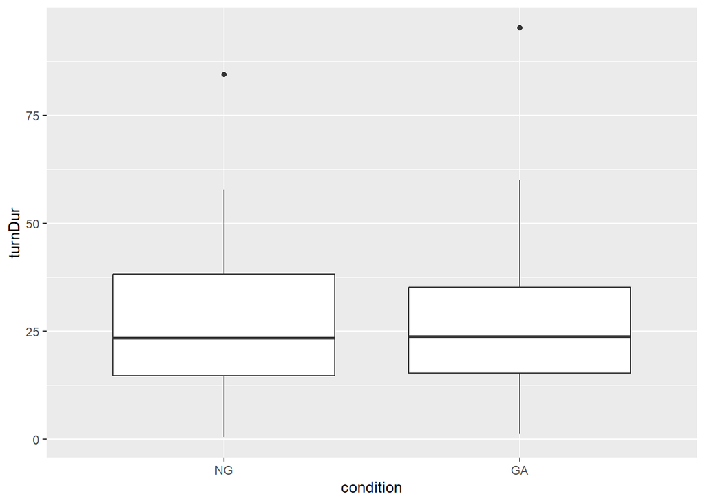

```r
ggplot(dac %>% filter(!grepl("Robot", speaker)), aes(condition, turnDur))+
  geom_boxplot()
```

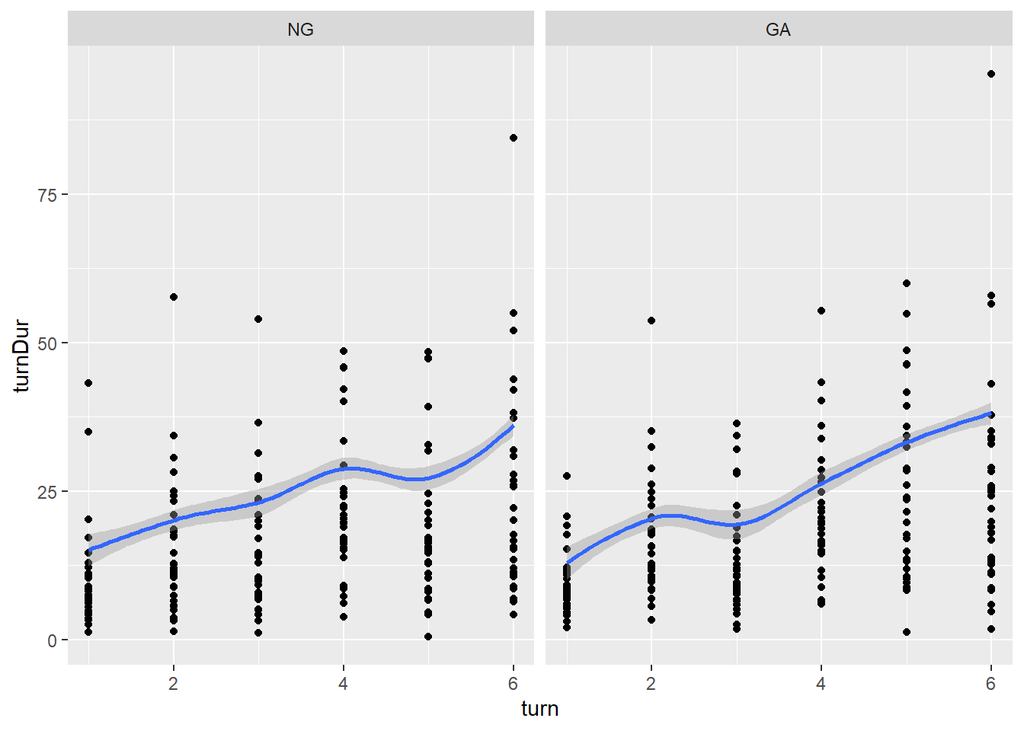

```r
ggplot(dac %>% filter(!grepl("Robot", speaker)), aes(turn, turnDur))+
  geom_point()+
  facet_wrap(~condition)+
  geom_smooth(method="loess")
```

- There is a `turn` effect: the further into the conversation, the longer the turns
- There is a `turn : condition` interaction: in the GA condition (robot looks away; i.e. objectively more humanlike) the turns get longer throughout the conversation

The order of the `turn` has a .95 correlation with `intimacy` ratings, since the questions always followed the same order. So we can’t say if turn duration got higher with the progression of the conversation or because the questions got more intimate, or simply because the questions got more elaborate (so people had more things to talk about).

So if we make a model with `turn` or `intimacy`, both give the same results – the one with `turn` showing slightly larger effect sizes. The model with `turn` also has considerably lower AIC.

```r
cor.test(dac$turn, dac$intimMean)
```

```
##
##  Pearson's product-moment correlation
##
## data:  dac$turn and dac$intimMean
## t = 145.37, df = 2506, p-value < 2.2e-16
## alternative hypothesis: true correlation is not equal to 0
## 95 percent confidence interval:
##  0.9412008 0.9495108
## sample estimates:
##       cor
## 0.9455096
```

```r
dac$condition <- relevel(dac$condition, ref="NG")
summary(t1 <- lmer(turnDur ~ condition * turn + (1 + condition | speaker), dac %>% filter(!grepl("Robot", speaker))))
```

```
## Linear mixed model fit by REML. t-tests use Satterthwaite's method [
## lmerModLmerTest]
## Formula: turnDur ~ condition * turn + (1 + condition | speaker)
##    Data: dac %>% filter(!grepl("Robot", speaker))
##
## REML criterion at convergence: 18438.8
##
## Scaled residuals:
##     Min      1Q  Median      3Q     Max
## -3.3865 -0.5933  0.0107  0.5872  3.0624
##
## Random effects:
##  Groups   Name        Variance Std.Dev. Corr
##  speaker  (Intercept) 132.95   11.530
##           conditionGA  49.83    7.059   -0.39
##  Residual              83.55    9.140
## Number of obs: 2508, groups:  speaker, 33
##
## Fixed effects:
##                   Estimate Std. Error        df t value Pr(>|t|)
## (Intercept)         8.6513     2.1268   38.9514   4.068 0.000224 ***
## conditionGA        -1.8008     1.5686   71.6639  -1.148 0.254796
## turn                3.2257     0.1647 2450.6120  19.581  < 2e-16 ***
## conditionGA:turn    0.9270     0.2292 2450.1402   4.044 5.41e-05 ***
## ---
## Signif. codes:  0 '***' 0.001 '**' 0.01 '*' 0.05 '.' 0.1 ' ' 1
##
## Correlation of Fixed Effects:
##             (Intr) cndtGA turn
## conditionGA -0.439
## turn        -0.298  0.405
## cndtnGA:trn  0.215 -0.564 -0.719
```

```r
summary(t2 <- lmer(turnDur ~ condition * intimMean + (1 + condition | speaker), dac %>% filter(!grepl("Robot", speaker))))
```

```
## Linear mixed model fit by REML. t-tests use Satterthwaite's method [
## lmerModLmerTest]
## Formula: turnDur ~ condition * intimMean + (1 + condition | speaker)
##    Data: dac %>% filter(!grepl("Robot", speaker))
##
## REML criterion at convergence: 18591.9
##
## Scaled residuals:
##     Min      1Q  Median      3Q     Max
## -2.9167 -0.6294  0.0391  0.6275  3.3052
##
## Random effects:
##  Groups   Name        Variance Std.Dev. Corr
##  speaker  (Intercept) 135.27   11.631
##           conditionGA  48.37    6.955   -0.41
##  Residual              88.96    9.432
## Number of obs: 2508, groups:  speaker, 33
##
## Fixed effects:
##                        Estimate Std. Error        df t value Pr(>|t|)
## (Intercept)              9.8895     2.1503   39.2781   4.599 4.34e-05 ***
## conditionGA             -1.4055     1.5646   75.0668  -0.898  0.37190
## intimMean                2.7034     0.1579 2459.4316  17.123  < 2e-16 ***
## conditionGA:intimMean    0.6993     0.2141 2453.3761   3.266  0.00111 **
## ---
## Signif. codes:  0 '***' 0.001 '**' 0.01 '*' 0.05 '.' 0.1 ' ' 1
##
## Correlation of Fixed Effects:
##             (Intr) cndtGA intmMn
## conditionGA -0.457
## intimMean   -0.304  0.419
## cndtnGA:ntM  0.225 -0.573 -0.738
```

```r
anova(t1, t2)
```

```
## refitting model(s) with ML (instead of REML)
```

```
## Data: dac %>% filter(!grepl("Robot", speaker))
## Models:
## t1: turnDur ~ condition * turn + (1 + condition | speaker)
## t2: turnDur ~ condition * intimMean + (1 + condition | speaker)
##    npar   AIC   BIC  logLik deviance Chisq Df Pr(>Chisq)
## t1    8 18457 18503 -9220.3    18441
## t2    8 18609 18656 -9296.7    18593     0  0
```

# f0 during conversation

## Look closer at f0 throughout time

(Check plots saved)

```r
# folderRobF0 <- "C:/Users/offredet/Documents/1HU/ExperimentEyes/Data/RobotsF0/"
# dat <- dac %>% filter(grepl("Robot", speaker))
#
# for(r in unique(dat$speaker)){
#   ggplot(dat %>% filter(speaker==r), aes(as.numeric(timeIndexOverall), f0mean))+
#     geom_point()+
#     facet_wrap(~condition)+
#     geom_smooth(method="loess")
#   ggsave(paste0(folderRobF0, r, ".png"))
# }
#
# folderPartF0 <- "C:/Users/offredet/Documents/1HU/ExperimentEyes/Data/ParticipantsF0/"
# dat <- dac %>% filter(!grepl("Robot", speaker))
#
# for(r in unique(dat$speaker)){
#   ggplot(dat %>% filter(speaker==r), aes(as.numeric(timeIndexOverall), f0mean))+
#     geom_point()+
#     facet_wrap(~condition)+
#     geom_smooth(method="loess")
#   ggsave(paste0(folderPartF0, r, ".png"))
# }
```

## Using the f0 from the IPUs of the robot’s previous turn as predictors for the f0 of the IPUs of the human’s current turn

### f0 mean

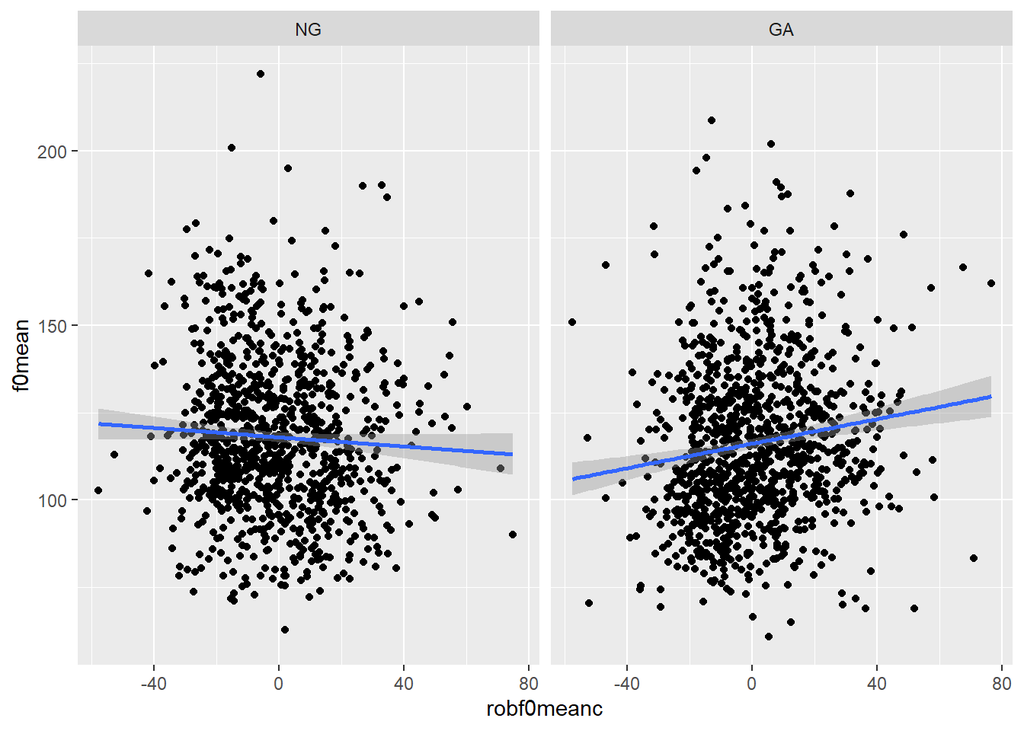

```r
ggplot(dac, aes(robf0meanc, f0mean))+
  geom_point()+
  facet_wrap(~condition)+
  geom_smooth(method="lm")
```

- Robot’s f0 mean predicts human’s f0 mean only in the **Gaze Aversion** condition. *Turn* did not improve the model.

```r
dac$condition <- relevel(dac$condition, ref="NG")
summary(f0 <- lmer(f0mean ~ robf0meanc + (1 | speaker), dac))
```

```
## Linear mixed model fit by REML. t-tests use Satterthwaite's method [
## lmerModLmerTest]
## Formula: f0mean ~ robf0meanc + (1 | speaker)
##    Data: dac
##
## REML criterion at convergence: 16571
##
## Scaled residuals:
##     Min      1Q  Median      3Q     Max
## -5.6326 -0.5996 -0.1542  0.4570  5.9505
##
## Random effects:
##  Groups   Name        Variance Std.Dev.
##  speaker  (Intercept) 302.5    17.39
##  Residual             220.5    14.85
## Number of obs: 1995, groups:  speaker, 33
##
## Fixed effects:
##              Estimate Std. Error        df t value Pr(>|t|)
## (Intercept) 1.159e+02  3.048e+00 3.206e+01  38.017  < 2e-16 ***
## robf0meanc  5.502e-02  1.781e-02 1.961e+03   3.089  0.00204 **
## ---
## Signif. codes:  0 '***' 0.001 '**' 0.01 '*' 0.05 '.' 0.1 ' ' 1
##
## Correlation of Fixed Effects:
##            (Intr)
## robf0meanc 0.000
```

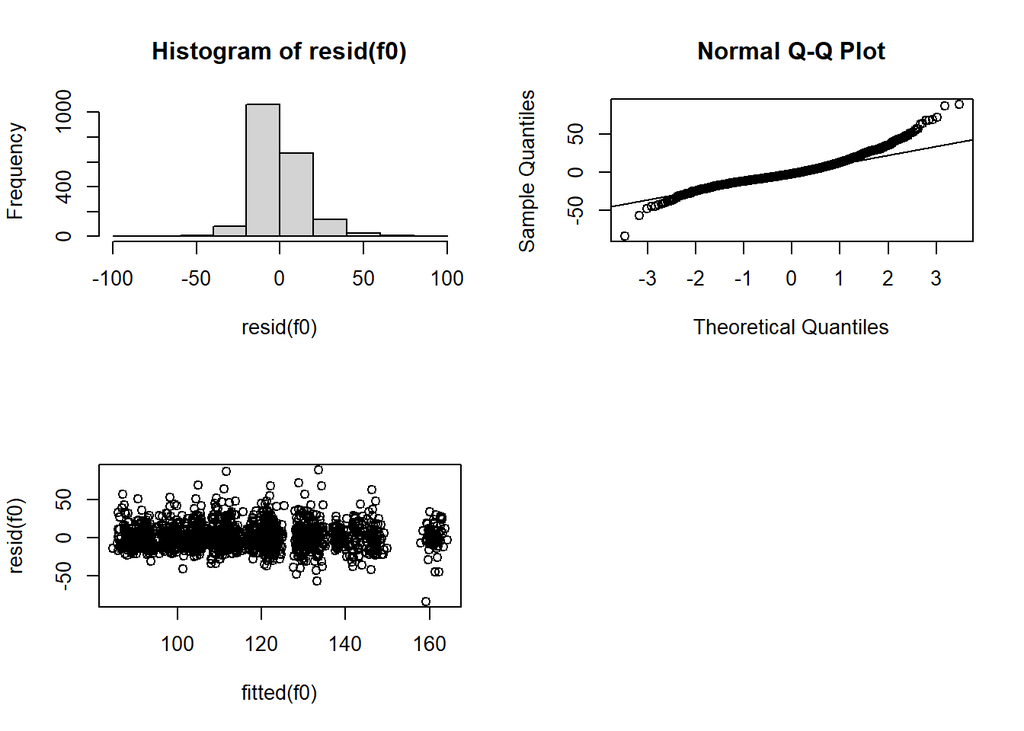

```r
par(mfrow=c(2,2))
hist(resid(f0))
qqnorm(resid(f0));qqline(resid(f0))
plot(fitted(f0), resid(f0))
```

### f0 SD

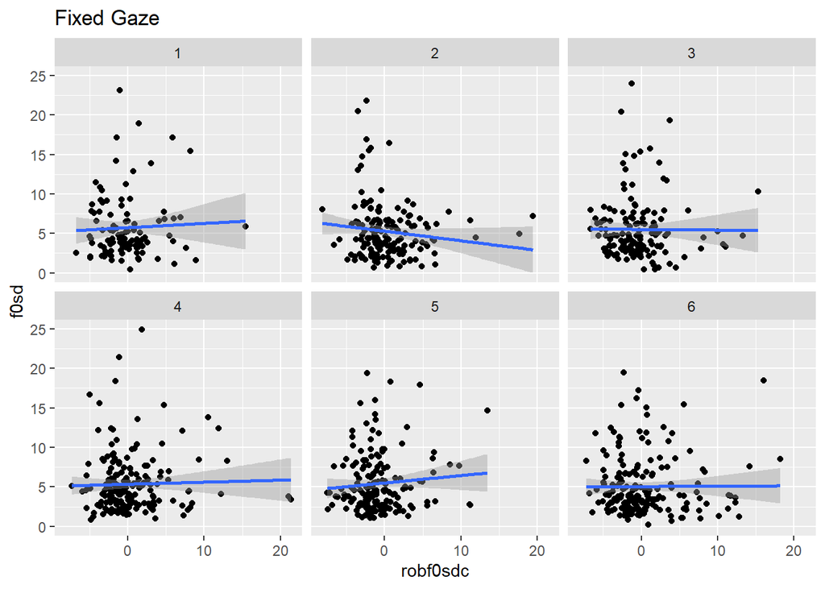

```r
ggplot(dac %>% filter(condition=="NG"), aes(robf0sdc, f0sd))+
  geom_point()+
  facet_wrap(~as.factor(turn))+
  geom_smooth(method="lm")+
  ggtitle("Fixed Gaze")
```

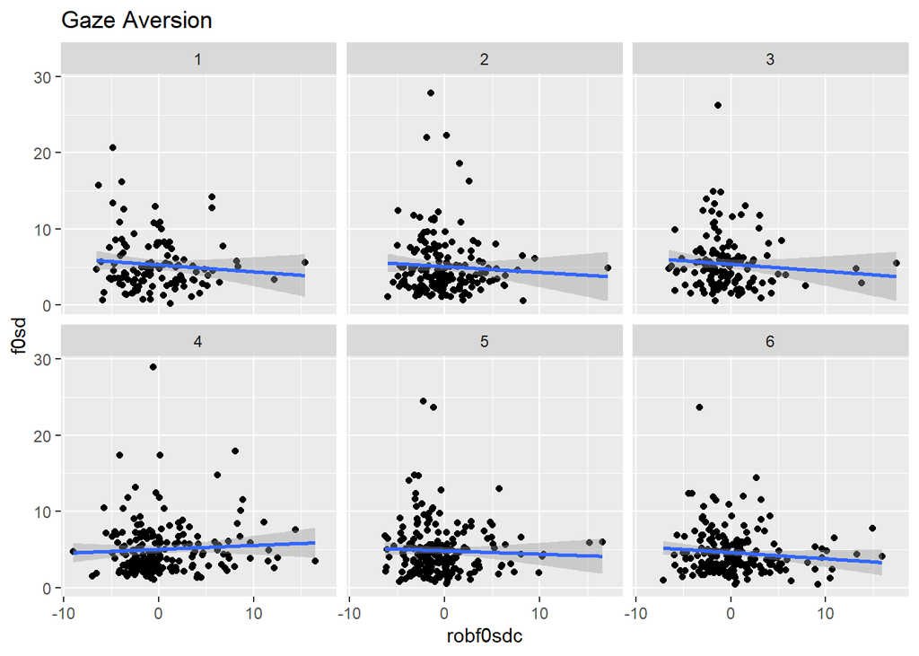

```r
ggplot(dac %>% filter(condition=="GA"), aes(robf0sdc, f0sd))+
  geom_point()+
  facet_wrap(~as.factor(turn))+
  geom_smooth(method="lm")+
  ggtitle("Gaze Aversion")
```

- There’s no effect on f0 SD.

```r
summary(f2 <- lmer(f0sd ~ robf0sdc : condition : turn + (1 + condition | speaker), dac))
```

```
## Linear mixed model fit by REML. t-tests use Satterthwaite's method [
## lmerModLmerTest]
## Formula: f0sd ~ robf0sdc:condition:turn + (1 + condition | speaker)
##    Data: dac
##
## REML criterion at convergence: 10326.1
##
## Scaled residuals:
##     Min      1Q  Median      3Q     Max
## -2.3320 -0.5763 -0.2018  0.3212  7.0214
##
## Random effects:
##  Groups   Name        Variance Std.Dev. Corr
##  speaker  (Intercept)  2.4296  1.5587
##           conditionGA  0.5555  0.7453   -0.38
##  Residual             10.7478  3.2784
## Number of obs: 1959, groups:  speaker, 33
##
## Fixed effects:
##                             Estimate Std. Error         df t value Pr(>|t|)
## (Intercept)                5.141e+00  2.637e-01  3.243e+01  19.494   <2e-16 ***
## robf0sdc:conditionNG:turn  2.154e-03  6.446e-03  1.919e+03   0.334    0.738
## robf0sdc:conditionGA:turn -1.088e-02  6.625e-03  1.921e+03  -1.642    0.101
## ---
## Signif. codes:  0 '***' 0.001 '**' 0.01 '*' 0.05 '.' 0.1 ' ' 1
##
## Correlation of Fixed Effects:
##             (Intr) r0:NG:
## rbf0sdc:NG: -0.002
## rbf0sdc:GA:  0.000 -0.007
```

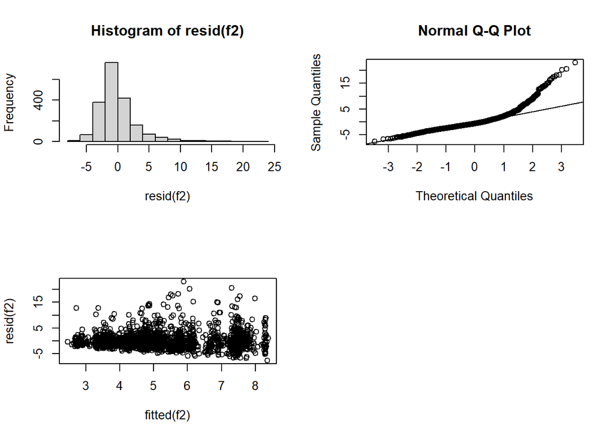

```r
par(mfrow=c(2,2))
hist(resid(f2))
qqnorm(resid(f2));qqline(resid(f2))
plot(fitted(f2), resid(f2))
```

#### checking with mock data

```r
summary(f1 <- lmer(f0sd ~ mockf0sdC : condition + (1 + condition | speaker), dac %>% filter(!grepl("Robot", speaker))))
```

```
## Linear mixed model fit by REML. t-tests use Satterthwaite's method [
## lmerModLmerTest]
## Formula: f0sd ~ mockf0sdC:condition + (1 + condition | speaker)
##    Data: dac %>% filter(!grepl("Robot", speaker))
##
## REML criterion at convergence: 10246.6
##
## Scaled residuals:
##     Min      1Q  Median      3Q     Max
## -2.2246 -0.5707 -0.1983  0.3230  6.9507
##
## Random effects:
##  Groups   Name        Variance Std.Dev. Corr
##  speaker  (Intercept)  2.3739  1.5407
##           conditionGA  0.3763  0.6135   -0.33
##  Residual             10.9786  3.3134
## Number of obs: 1938, groups:  speaker, 33
##
## Fixed effects:
##                         Estimate Std. Error         df t value Pr(>|t|)
## (Intercept)              5.17912    0.26689   32.41140  19.406   <2e-16 ***
## mockf0sdC:conditionNG   -0.03912    0.02869 1901.29466  -1.364    0.173
## mockf0sdC:conditionGA   -0.01702    0.02621 1898.98404  -0.650    0.516
## ---
## Signif. codes:  0 '***' 0.001 '**' 0.01 '*' 0.05 '.' 0.1 ' ' 1
##
## Correlation of Fixed Effects:
##             (Intr) m0C:NG
## mckf0sdC:NG  0.004
## mckf0sdC:GA -0.004 -0.009
```

```r
summary(f2 <- lmer(f0sd ~ mockf0sdC : condition : turn + (1 + condition | speaker), dac %>% filter(!grepl("Robot", speaker))))
```

```
## Linear mixed model fit by REML. t-tests use Satterthwaite's method [
## lmerModLmerTest]
## Formula: f0sd ~ mockf0sdC:condition:turn + (1 + condition | speaker)
##    Data: dac %>% filter(!grepl("Robot", speaker))
##
## REML criterion at convergence: 10253.1
##
## Scaled residuals:
##     Min      1Q  Median      3Q     Max
## -2.2377 -0.5724 -0.1996  0.3181  6.9430
##
## Random effects:
##  Groups   Name        Variance Std.Dev. Corr
##  speaker  (Intercept)  2.3802  1.5428
##           conditionGA  0.3719  0.6099   -0.33
##  Residual             10.9831  3.3141
## Number of obs: 1938, groups:  speaker, 33
##
## Fixed effects:
##                              Estimate Std. Error         df t value Pr(>|t|)
## (Intercept)                 5.179e+00  2.671e-01  3.240e+01  19.391   <2e-16
## mockf0sdC:conditionNG:turn -3.809e-03  6.896e-03  1.902e+03  -0.552    0.581
## mockf0sdC:conditionGA:turn -6.891e-03  6.116e-03  1.901e+03  -1.127    0.260
##
## (Intercept)                ***
## mockf0sdC:conditionNG:turn
## mockf0sdC:conditionGA:turn
## ---
## Signif. codes:  0 '***' 0.001 '**' 0.01 '*' 0.05 '.' 0.1 ' ' 1
##
## Correlation of Fixed Effects:
##             (Intr) m0C:NG
## mckf0sC:NG:  0.001
## mckf0sC:GA: -0.001 -0.009
```

```r
anova(f1,f2)
```

```
## refitting model(s) with ML (instead of REML)
```

```
## Data: dac %>% filter(!grepl("Robot", speaker))
## Models:
## f1: f0sd ~ mockf0sdC:condition + (1 + condition | speaker)
## f2: f0sd ~ mockf0sdC:condition:turn + (1 + condition | speaker)
##    npar   AIC   BIC  logLik deviance Chisq Df Pr(>Chisq)
## f1    7 10249 10288 -5117.6    10235
## f2    7 10250 10289 -5117.9    10236     0  0
```

#### checking with mock data

- The mock data also shows no effect.

```r
summary(f1 <- lmer(f0sd ~ mockf0CVc : condition + (1 + condition | speaker), dac))
```

```
## Linear mixed model fit by REML. t-tests use Satterthwaite's method [
## lmerModLmerTest]
## Formula: f0sd ~ mockf0CVc:condition + (1 + condition | speaker)
##    Data: dac
##
## REML criterion at convergence: 10226.9
##
## Scaled residuals:
##     Min      1Q  Median      3Q     Max
## -2.2359 -0.5700 -0.1947  0.3161  6.9505
##
## Random effects:
##  Groups   Name        Variance Std.Dev. Corr
##  speaker  (Intercept)  2.3606  1.536
##           conditionGA  0.3856  0.621    -0.32
##  Residual             10.9761  3.313
## Number of obs: 1938, groups:  speaker, 33
##
## Fixed effects:
##                        Estimate Std. Error        df t value Pr(>|t|)
## (Intercept)              5.1832     0.2668   32.4027  19.427   <2e-16 ***
## mockf0CVc:conditionNG   -5.1677     3.7814 1898.9148  -1.367    0.172
## mockf0CVc:conditionGA   -2.6935     3.4960 1898.4971  -0.770    0.441
## ---
## Signif. codes:  0 '***' 0.001 '**' 0.01 '*' 0.05 '.' 0.1 ' ' 1
##
## Correlation of Fixed Effects:
##             (Intr) m0CV:N
## mckf0CVc:NG  0.004
## mckf0CVc:GA -0.004 -0.008
```

### f0 coefficient of variation

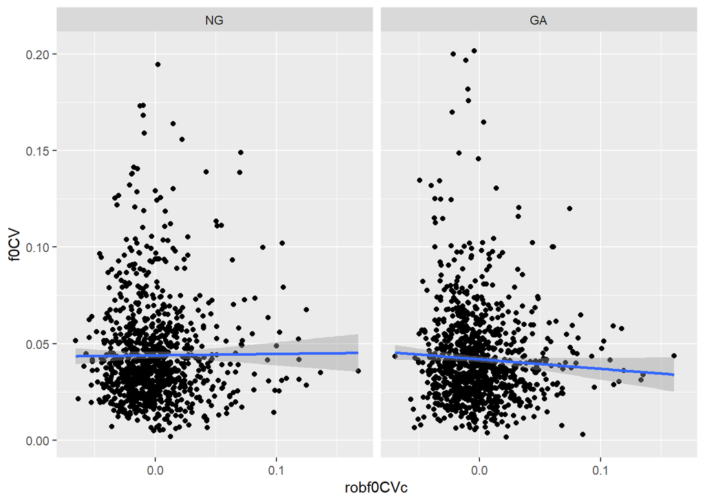

```r
ggplot(dac, aes(robf0CVc, f0CV))+
  geom_point()+
  facet_wrap(~condition)+
  geom_smooth(method="lm")
```

- Like for f0 SD, there is no effect on f0 coefficient of variation.

```r
summary(f1 <- lmer(f0CV ~ robf0CVc : condition + (1 + condition | speaker), dac))
```

```
## Linear mixed model fit by REML. t-tests use Satterthwaite's method [
## lmerModLmerTest]
## Formula: f0CV ~ robf0CVc:condition + (1 + condition | speaker)
##    Data: dac
##
## REML criterion at convergence: -8874
##
## Scaled residuals:
##     Min      1Q  Median      3Q     Max
## -1.9375 -0.5960 -0.1824  0.3487  6.1636
##
## Random effects:
##  Groups   Name        Variance  Std.Dev. Corr
##  speaker  (Intercept) 7.055e-05 0.008399
##           conditionGA 3.107e-05 0.005574 -0.43
##  Residual             6.002e-04 0.024499
## Number of obs: 1959, groups:  speaker, 33
##
## Fixed effects:
##                        Estimate Std. Error         df t value Pr(>|t|)
## (Intercept)           4.319e-02  1.443e-03  3.249e+01  29.929   <2e-16 ***
## robf0CVc:conditionNG  5.026e-04  2.707e-02  1.922e+03   0.019    0.985
## robf0CVc:conditionGA -4.398e-02  2.741e-02  1.924e+03  -1.604    0.109
## ---
## Signif. codes:  0 '***' 0.001 '**' 0.01 '*' 0.05 '.' 0.1 ' ' 1
##
## Correlation of Fixed Effects:
##             (Intr) r0CV:N
## rbf0CVc:cNG -0.003
## rbf0CVc:cGA  0.005 -0.008
```

```r
summary(f2 <- lmer(f0CV ~ robf0CVc : condition : turn + (1 + condition | speaker), dac))
```

```
## Linear mixed model fit by REML. t-tests use Satterthwaite's method [
## lmerModLmerTest]
## Formula: f0CV ~ robf0CVc:condition:turn + (1 + condition | speaker)
##    Data: dac
##
## REML criterion at convergence: -8867.9
##
## Scaled residuals:
##     Min      1Q  Median      3Q     Max
## -1.9427 -0.5965 -0.1844  0.3466  6.1749
##
## Random effects:
##  Groups   Name        Variance  Std.Dev. Corr
##  speaker  (Intercept) 7.048e-05 0.008395
##           conditionGA 3.092e-05 0.005560 -0.43
##  Residual             6.003e-04 0.024502
## Number of obs: 1959, groups:  speaker, 33
##
## Fixed effects:
##                             Estimate Std. Error         df t value Pr(>|t|)
## (Intercept)                4.320e-02  1.445e-03  3.249e+01  29.894   <2e-16 ***
## robf0CVc:conditionNG:turn  1.143e-03  6.360e-03  1.923e+03   0.180    0.857
## robf0CVc:conditionGA:turn -9.760e-03  6.659e-03  1.923e+03  -1.466    0.143
## ---
## Signif. codes:  0 '***' 0.001 '**' 0.01 '*' 0.05 '.' 0.1 ' ' 1
##
## Correlation of Fixed Effects:
##             (Intr) r0CV:N
## rbf0CVc:NG: -0.003
## rbf0CVc:GA:  0.001 -0.008
```

```r
anova(f1,f2)
```

```
## refitting model(s) with ML (instead of REML)
```

```
## Data: dac
## Models:
## f1: f0CV ~ robf0CVc:condition + (1 + condition | speaker)
## f2: f0CV ~ robf0CVc:condition:turn + (1 + condition | speaker)
##    npar     AIC     BIC logLik deviance Chisq Df Pr(>Chisq)
## f1    7 -8882.0 -8843.0 4448.0  -8896.0
## f2    7 -8881.6 -8842.6 4447.8  -8895.6     0  0
```

### Comparing beginning and end of dialogue

No convergence

### Intimacy

#### f0 mean

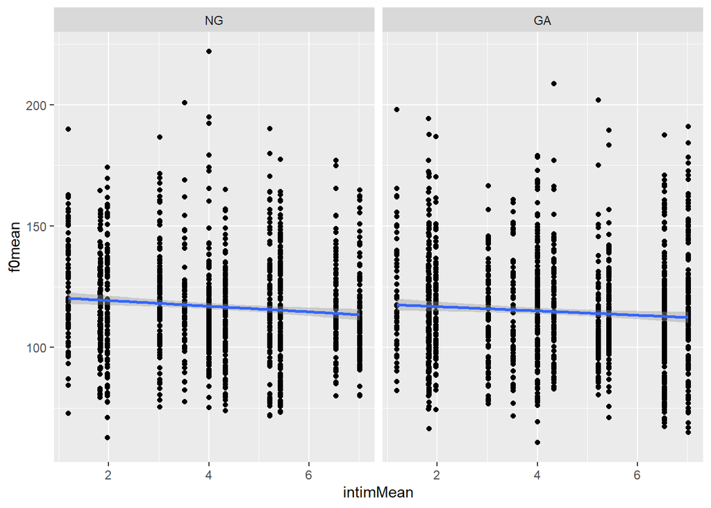

```r
ggplot(dac, aes(intimMean, f0mean))+
  geom_point()+
  facet_wrap(~condition)+
  geom_smooth(method="lm")
```

```r
summary(f1a <- lmer(f0mean ~ intimc + (1  | speaker), dac))
```

```
## Linear mixed model fit by REML. t-tests use Satterthwaite's method [
## lmerModLmerTest]
## Formula: f0mean ~ intimc + (1 | speaker)
##    Data: dac
##
## REML criterion at convergence: 20660.8
##
## Scaled residuals:
##     Min      1Q  Median      3Q     Max
## -5.7317 -0.5819 -0.1474  0.4452  6.0818
##
## Random effects:
##  Groups   Name        Variance Std.Dev.
##  speaker  (Intercept) 309.1    17.58
##  Residual             208.7    14.45
## Number of obs: 2508, groups:  speaker, 33
##
## Fixed effects:
##              Estimate Std. Error        df t value Pr(>|t|)
## (Intercept)  115.1420     3.0772   32.0396   37.42  < 2e-16 ***
## intimc        -0.8698     0.1584 2474.0412   -5.49 4.42e-08 ***
## ---
## Signif. codes:  0 '***' 0.001 '**' 0.01 '*' 0.05 '.' 0.1 ' ' 1
##
## Correlation of Fixed Effects:
##        (Intr)
## intimc 0.000
```

```r
summary(f1b <- lmer(f0mean ~ intimc : condition  + (1 | speaker), dac))
```

```
## Linear mixed model fit by REML. t-tests use Satterthwaite's method [
## lmerModLmerTest]
## Formula: f0mean ~ intimc:condition + (1 | speaker)
##    Data: dac
##
## REML criterion at convergence: 20658.2
##
## Scaled residuals:
##     Min      1Q  Median      3Q     Max
## -5.7051 -0.5849 -0.1518  0.4469  6.0947
##
## Random effects:
##  Groups   Name        Variance Std.Dev.
##  speaker  (Intercept) 309.7    17.60
##  Residual             208.5    14.44
## Number of obs: 2508, groups:  speaker, 33
##
## Fixed effects:
##                     Estimate Std. Error        df t value Pr(>|t|)
## (Intercept)         115.1527     3.0802   32.0392  37.384  < 2e-16 ***
## intimc:conditionNG   -0.5614     0.2377 2474.4680  -2.362   0.0183 *
## intimc:conditionGA   -1.1315     0.2184 2474.2602  -5.180  2.4e-07 ***
## ---
## Signif. codes:  0 '***' 0.001 '**' 0.01 '*' 0.05 '.' 0.1 ' ' 1
##
## Correlation of Fixed Effects:
##             (Intr) int:NG
## intmc:cndNG  0.001
## intmc:cndGA -0.001 -0.031
```

```r
anova(f1a, f1b)
```

```
## refitting model(s) with ML (instead of REML)
```

```
## Data: dac
## Models:
## f1a: f0mean ~ intimc + (1 | speaker)
## f1b: f0mean ~ intimc:condition + (1 | speaker)
##     npar   AIC   BIC logLik deviance  Chisq Df Pr(>Chisq)
## f1a    4 20671 20694 -10332    20663
## f1b    5 20670 20699 -10330    20660 3.0228  1     0.0821 .
## ---
## Signif. codes:  0 '***' 0.001 '**' 0.01 '*' 0.05 '.' 0.1 ' ' 1
```

```r
summary(f1 <- lmer(intensMean ~ intimc + (1  | speaker), dac))
```

```
## Linear mixed model fit by REML. t-tests use Satterthwaite's method [
## lmerModLmerTest]
## Formula: intensMean ~ intimc + (1 | speaker)
##    Data: dac
##
## REML criterion at convergence: 12912.4
##
## Scaled residuals:
##     Min      1Q  Median      3Q     Max
## -4.1570 -0.5448  0.0439  0.5872  3.4600
##
## Random effects:
##  Groups   Name        Variance Std.Dev.
##  speaker  (Intercept) 5.182    2.276
##  Residual             9.599    3.098
## Number of obs: 2508, groups:  speaker, 33
##
## Fixed effects:
##               Estimate Std. Error         df t value Pr(>|t|)
## (Intercept)   70.90339    0.40219   32.15953 176.294   <2e-16 ***
## intimc        -0.07359    0.03397 2474.17066  -2.166   0.0304 *
## ---
## Signif. codes:  0 '***' 0.001 '**' 0.01 '*' 0.05 '.' 0.1 ' ' 1
##
## Correlation of Fixed Effects:
##        (Intr)
## intimc 0.000
```

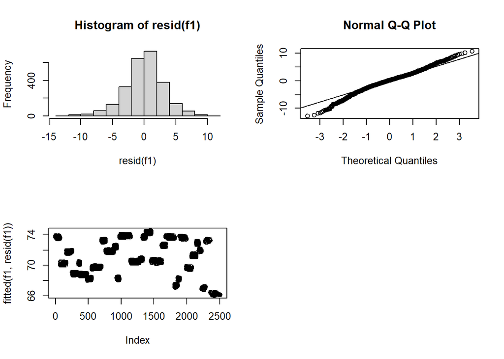

```r
par(mfrow=c(2,2))
hist(resid(f1))
qqnorm(resid(f1));qqline(resid(f1))
plot(fitted(f1, resid(f1)))
```

#### f0 SD

```r
summary(f1 <- lmer(f0sd ~ intimc + (1 | speaker), dac))
```

```
## Linear mixed model fit by REML. t-tests use Satterthwaite's method [
## lmerModLmerTest]
## Formula: f0sd ~ intimc + (1 | speaker)
##    Data: dac
##
## REML criterion at convergence: 12919.6
##
## Scaled residuals:
##     Min      1Q  Median      3Q     Max
## -2.1114 -0.5675 -0.1867  0.3086  7.3227
##
## Random effects:
##  Groups   Name        Variance Std.Dev.
##  speaker  (Intercept)  2.086   1.444
##  Residual             10.193   3.193
## Number of obs: 2486, groups:  speaker, 33
##
## Fixed effects:
##               Estimate Std. Error         df t value Pr(>|t|)
## (Intercept)    5.09122    0.26126   32.51016   19.49  < 2e-16 ***
## intimc        -0.12147    0.03511 2452.59536   -3.46  0.00055 ***
## ---
## Signif. codes:  0 '***' 0.001 '**' 0.01 '*' 0.05 '.' 0.1 ' ' 1
##
## Correlation of Fixed Effects:
##        (Intr)
## intimc 0.000
```

```r
summary(f1i <- lmer(intensMean ~ intimc  + (1  | speaker), dac))
```

```
## Linear mixed model fit by REML. t-tests use Satterthwaite's method [
## lmerModLmerTest]
## Formula: intensMean ~ intimc + (1 | speaker)
##    Data: dac
##
## REML criterion at convergence: 12912.4
##
## Scaled residuals:
##     Min      1Q  Median      3Q     Max
## -4.1570 -0.5448  0.0439  0.5872  3.4600
##
## Random effects:
##  Groups   Name        Variance Std.Dev.
##  speaker  (Intercept) 5.182    2.276
##  Residual             9.599    3.098
## Number of obs: 2508, groups:  speaker, 33
##
## Fixed effects:
##               Estimate Std. Error         df t value Pr(>|t|)
## (Intercept)   70.90339    0.40219   32.15953 176.294   <2e-16 ***
## intimc        -0.07359    0.03397 2474.17066  -2.166   0.0304 *
## ---
## Signif. codes:  0 '***' 0.001 '**' 0.01 '*' 0.05 '.' 0.1 ' ' 1
##
## Correlation of Fixed Effects:
##        (Intr)
## intimc 0.000
```

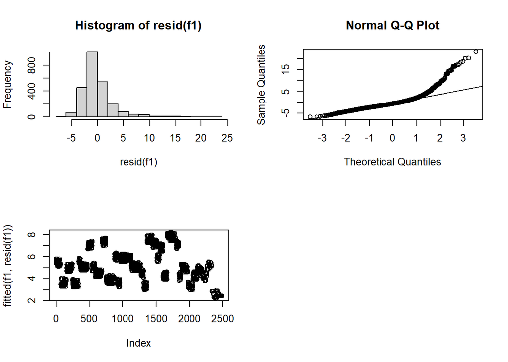

```r
par(mfrow=c(2,2))
hist(resid(f1))
qqnorm(resid(f1));qqline(resid(f1))
plot(fitted(f1, resid(f1)))
```

### BFI

**Conclusion** about BFI dimesions:

Maybe emotional stability (I think also called neuroticism) is the only potentially good predictor.

#### Intellect/Openness

```r
summary(intel1 <- lmer(f0mean ~ robf0meanc : IOc : condition + (1 + condition | speaker), dac %>% filter(!grepl("Robot", speaker))))
```

```
## Linear mixed model fit by REML. t-tests use Satterthwaite's method [
## lmerModLmerTest]
## Formula: f0mean ~ robf0meanc:IOc:condition + (1 + condition | speaker)
##    Data: dac %>% filter(!grepl("Robot", speaker))
##
## REML criterion at convergence: 16568.2
##
## Scaled residuals:
##     Min      1Q  Median      3Q     Max
## -5.8808 -0.5993 -0.1572  0.4683  5.8404
##
## Random effects:
##  Groups   Name        Variance Std.Dev. Corr
##  speaker  (Intercept) 296.83   17.229
##           conditionGA  16.38    4.047   -0.02
##  Residual             217.36   14.743
## Number of obs: 1995, groups:  speaker, 33
##
## Fixed effects:
##                             Estimate Std. Error        df t value Pr(>|t|)
## (Intercept)                1.161e+02  3.027e+00 3.202e+01  38.369   <2e-16 ***
## robf0meanc:IOc:conditionNG 4.465e-02  5.190e-02 1.470e+03   0.860    0.390
## robf0meanc:IOc:conditionGA 6.546e-02  4.303e-02 1.864e+03   1.521    0.128
## ---
## Signif. codes:  0 '***' 0.001 '**' 0.01 '*' 0.05 '.' 0.1 ' ' 1
##
## Correlation of Fixed Effects:
##             (Intr) r0:IO:N
## rbf0m:IO:NG  0.012
## rbf0m:IO:GA -0.004 -0.065
```

```r
summary(no1 <- lmer(f0mean ~ robf0meanc : condition : turn + (1 + condition | speaker), dac %>% filter(!grepl("Robot", speaker))))
```

```
## Linear mixed model fit by REML. t-tests use Satterthwaite's method [
## lmerModLmerTest]
## Formula: f0mean ~ robf0meanc:condition:turn + (1 + condition | speaker)
##    Data: dac %>% filter(!grepl("Robot", speaker))
##
## REML criterion at convergence: 16571.2
##
## Scaled residuals:
##     Min      1Q  Median      3Q     Max
## -5.6576 -0.6032 -0.1654  0.4721  5.8694
##
## Random effects:
##  Groups   Name        Variance Std.Dev. Corr
##  speaker  (Intercept) 297.69   17.254
##           conditionGA  15.86    3.982   -0.03
##  Residual             216.88   14.727
## Number of obs: 1995, groups:  speaker, 33
##
## Fixed effects:
##                              Estimate Std. Error        df t value Pr(>|t|)
## (Intercept)                 1.161e+02  3.028e+00 3.203e+01  38.347   <2e-16 ***
## robf0meanc:conditionNG:turn 1.078e-02  6.671e-03 1.616e+03   1.616    0.106
## robf0meanc:conditionGA:turn 1.464e-02  6.572e-03 1.715e+03   2.228    0.026 *
## ---
## Signif. codes:  0 '***' 0.001 '**' 0.01 '*' 0.05 '.' 0.1 ' ' 1
##
## Correlation of Fixed Effects:
##             (Intr) r0:NG:
## rbf0mnc:NG:  0.007
## rbf0mnc:GA: -0.002 -0.066
```

```r
anova(intel1, no1)
```

```
## refitting model(s) with ML (instead of REML)
```

```
## Data: dac %>% filter(!grepl("Robot", speaker))
## Models:
## intel1: f0mean ~ robf0meanc:IOc:condition + (1 + condition | speaker)
## no1: f0mean ~ robf0meanc:condition:turn + (1 + condition | speaker)
##        npar   AIC   BIC  logLik deviance  Chisq Df Pr(>Chisq)
## intel1    7 16578 16617 -8281.8    16564
## no1       7 16573 16612 -8279.4    16559 4.8064  0
```

#### Agreeableness

```r
d <- dac %>%
  filter(!grepl("Robot", speaker)) %>%
  select(f0mean, robf0meanc, Agreec, Agreeableness, condition, speaker, turn) %>%
  na.omit()

summary(agree1 <- lmer(f0mean ~ robf0meanc : Agreec : condition + (1 +condition| speaker), d))
```

```
## Linear mixed model fit by REML. t-tests use Satterthwaite's method [
## lmerModLmerTest]
## Formula: f0mean ~ robf0meanc:Agreec:condition + (1 + condition | speaker)
##    Data: d
##
## REML criterion at convergence: 16115.2
##
## Scaled residuals:
##     Min      1Q  Median      3Q     Max
## -5.8857 -0.6042 -0.1635  0.4723  5.8085
##
## Random effects:
##  Groups   Name        Variance Std.Dev. Corr
##  speaker  (Intercept) 296.42   17.217
##           conditionGA  17.09    4.135   0.04
##  Residual             219.87   14.828
## Number of obs: 1938, groups:  speaker, 32
##
## Fixed effects:
##                                Estimate Std. Error        df t value Pr(>|t|)
## (Intercept)                   1.158e+02  3.082e+00 3.102e+01  37.572   <2e-16
## robf0meanc:Agreec:conditionNG 5.730e-02  8.257e-02 1.183e+03   0.694    0.488
## robf0meanc:Agreec:conditionGA 6.913e-02  6.694e-02 1.537e+03   1.033    0.302
##
## (Intercept)                   ***
## robf0meanc:Agreec:conditionNG
## robf0meanc:Agreec:conditionGA
## ---
## Signif. codes:  0 '***' 0.001 '**' 0.01 '*' 0.05 '.' 0.1 ' ' 1
##
## Correlation of Fixed Effects:
##             (Intr) r0:A:N
## rbf0mn:A:NG  0.002
## rbf0mn:A:GA  0.000 -0.096
```

```r
summary(no1 <- lmer(f0mean ~ robf0meanc : condition : turn + (1+condition | speaker), d))
```

```
## Linear mixed model fit by REML. t-tests use Satterthwaite's method [
## lmerModLmerTest]
## Formula: f0mean ~ robf0meanc:condition:turn + (1 + condition | speaker)
##    Data: d
##
## REML criterion at convergence: 16119.2
##
## Scaled residuals:
##     Min      1Q  Median      3Q     Max
## -5.6422 -0.6049 -0.1667  0.4695  5.8395
##
## Random effects:
##  Groups   Name        Variance Std.Dev. Corr
##  speaker  (Intercept) 300.88   17.346
##           conditionGA  16.54    4.067   -0.03
##  Residual             219.24   14.807
## Number of obs: 1938, groups:  speaker, 32
##
## Fixed effects:
##                              Estimate Std. Error        df t value Pr(>|t|)
## (Intercept)                 1.157e+02  3.093e+00 3.103e+01  37.407   <2e-16 ***
## robf0meanc:conditionNG:turn 1.135e-02  6.806e-03 1.566e+03   1.668   0.0955 .
## robf0meanc:conditionGA:turn 1.364e-02  6.674e-03 1.674e+03   2.044   0.0412 *
## ---
## Signif. codes:  0 '***' 0.001 '**' 0.01 '*' 0.05 '.' 0.1 ' ' 1
##
## Correlation of Fixed Effects:
##             (Intr) r0:NG:
## rbf0mnc:NG:  0.009
## rbf0mnc:GA: -0.003 -0.066
```

```r
anova(agree1, no1)
```

```
## refitting model(s) with ML (instead of REML)
```

```
## Data: d
## Models:
## agree1: f0mean ~ robf0meanc:Agreec:condition + (1 + condition | speaker)
## no1: f0mean ~ robf0meanc:condition:turn + (1 + condition | speaker)
##        npar   AIC   BIC  logLik deviance  Chisq Df Pr(>Chisq)
## agree1    7 16127 16166 -8056.3    16113
## no1       7 16121 16160 -8053.5    16107 5.6774  0
```

#### Conscientiousness

```r
d <- dac %>%
  filter(!grepl("Robot", speaker)) %>%
  select(f0mean, robf0meanc, Conscc, condition, speaker, turn)%>%
  na.omit()

summary(con1 <- lmer(f0mean ~ robf0meanc : Conscc : condition+ (1 + condition | speaker), d))
```

```
## Linear mixed model fit by REML. t-tests use Satterthwaite's method [
## lmerModLmerTest]
## Formula: f0mean ~ robf0meanc:Conscc:condition + (1 + condition | speaker)
##    Data: d
##
## REML criterion at convergence: 16118.3
##
## Scaled residuals:
##     Min      1Q  Median      3Q     Max
## -5.8498 -0.6087 -0.1594  0.4703  5.7911
##
## Random effects:
##  Groups   Name        Variance Std.Dev. Corr
##  speaker  (Intercept) 298.03   17.264
##           conditionGA  18.02    4.245   0.01
##  Residual             219.93   14.830
## Number of obs: 1938, groups:  speaker, 32
##
## Fixed effects:
##                                 Estimate Std. Error         df t value Pr(>|t|)
## (Intercept)                    115.71256    3.08873   31.10617  37.463   <2e-16
## robf0meanc:Conscc:conditionNG    0.01410    0.05234 1271.86483   0.269    0.788
## robf0meanc:Conscc:conditionGA   -0.01430    0.05024 1570.26162  -0.285    0.776
##
## (Intercept)                   ***
## robf0meanc:Conscc:conditionNG
## robf0meanc:Conscc:conditionGA
## ---
## Signif. codes:  0 '***' 0.001 '**' 0.01 '*' 0.05 '.' 0.1 ' ' 1
##
## Correlation of Fixed Effects:
##             (Intr) r0:C:N
## rbf0mn:C:NG -0.034
## rbf0mn:C:GA  0.015 -0.110
```

```r
summary(no1 <- lmer(f0mean ~ robf0meanc : condition: turn + (1 + condition | speaker), d))
```

```
## Linear mixed model fit by REML. t-tests use Satterthwaite's method [
## lmerModLmerTest]
## Formula: f0mean ~ robf0meanc:condition:turn + (1 + condition | speaker)
##    Data: d
##
## REML criterion at convergence: 16119.2
##
## Scaled residuals:
##     Min      1Q  Median      3Q     Max
## -5.6422 -0.6049 -0.1667  0.4695  5.8395
##
## Random effects:
##  Groups   Name        Variance Std.Dev. Corr
##  speaker  (Intercept) 300.88   17.346
##           conditionGA  16.54    4.067   -0.03
##  Residual             219.24   14.807
## Number of obs: 1938, groups:  speaker, 32
##
## Fixed effects:
##                              Estimate Std. Error        df t value Pr(>|t|)
## (Intercept)                 1.157e+02  3.093e+00 3.103e+01  37.407   <2e-16 ***
## robf0meanc:conditionNG:turn 1.135e-02  6.806e-03 1.566e+03   1.668   0.0955 .
## robf0meanc:conditionGA:turn 1.364e-02  6.674e-03 1.674e+03   2.044   0.0412 *
## ---
## Signif. codes:  0 '***' 0.001 '**' 0.01 '*' 0.05 '.' 0.1 ' ' 1
##
## Correlation of Fixed Effects:
##             (Intr) r0:NG:
## rbf0mnc:NG:  0.009
## rbf0mnc:GA: -0.003 -0.066
```

```r
anova(con1, no1)
```

```
## refitting model(s) with ML (instead of REML)
```

```
## Data: d
## Models:
## con1: f0mean ~ robf0meanc:Conscc:condition + (1 + condition | speaker)
## no1: f0mean ~ robf0meanc:condition:turn + (1 + condition | speaker)
##      npar   AIC   BIC  logLik deviance  Chisq Df Pr(>Chisq)
## con1    7 16128 16167 -8057.1    16114
## no1     7 16121 16160 -8053.5    16107 7.2317  0
```

#### EmotionalStability

```r
d <- dac %>%
  filter(!grepl("Robot", speaker)) %>%
  select(f0mean, f0meanZ, robf0meanZ,  robf0meanc, robPrevf0mean, ESc, EmotionalStability, condition, turn, speaker, intimc) %>%
  na.omit()

summary(em1c <- lmer(f0mean ~ robf0meanc : ESc  : condition + (1+condition | speaker), dac))
```

```
## Linear mixed model fit by REML. t-tests use Satterthwaite's method [
## lmerModLmerTest]
## Formula: f0mean ~ robf0meanc:ESc:condition + (1 + condition | speaker)
##    Data: dac
##
## REML criterion at convergence: 16119.2
##
## Scaled residuals:
##     Min      1Q  Median      3Q     Max
## -5.8127 -0.6066 -0.1636  0.4672  5.8202
##
## Random effects:
##  Groups   Name        Variance Std.Dev. Corr
##  speaker  (Intercept) 298.42   17.275
##           conditionGA  19.02    4.362   0.00
##  Residual             219.75   14.824
## Number of obs: 1938, groups:  speaker, 32
##
## Fixed effects:
##                             Estimate Std. Error        df t value Pr(>|t|)
## (Intercept)                1.158e+02  3.089e+00 3.109e+01  37.495   <2e-16 ***
## robf0meanc:ESc:conditionNG 3.293e-02  3.776e-02 1.267e+03   0.872    0.383
## robf0meanc:ESc:conditionGA 3.543e-03  3.138e-02 1.713e+03   0.113    0.910
## ---
## Signif. codes:  0 '***' 0.001 '**' 0.01 '*' 0.05 '.' 0.1 ' ' 1
##
## Correlation of Fixed Effects:
##             (Intr) r0:ES:N
## rbf0m:ES:NG  0.031
## rbf0m:ES:GA -0.008 -0.078
```

```r
# with mock data
summary(em0c <- lmer(f0mean ~ mockf0meanC : ESc : turn + intensMeanC + (1 | speaker), dac))
```

```
## Linear mixed model fit by REML. t-tests use Satterthwaite's method [
## lmerModLmerTest]
## Formula: f0mean ~ mockf0meanC:ESc:turn + intensMeanC + (1 | speaker)
##    Data: dac
##
## REML criterion at convergence: 15723.8
##
## Scaled residuals:
##     Min      1Q  Median      3Q     Max
## -6.1288 -0.5967 -0.1666  0.4262  6.3868
##
## Random effects:
##  Groups   Name        Variance Std.Dev.
##  speaker  (Intercept) 314.1    17.72
##  Residual             201.2    14.18
## Number of obs: 1913, groups:  speaker, 32
##
## Fixed effects:
##                       Estimate Std. Error        df t value Pr(>|t|)
## (Intercept)          1.153e+02  3.152e+00 3.104e+01  36.592   <2e-16 ***
## intensMeanC          1.601e+00  1.101e-01 1.879e+03  14.546   <2e-16 ***
## mockf0meanC:ESc:turn 6.003e-03  5.025e-03 1.879e+03   1.195    0.232
## ---
## Signif. codes:  0 '***' 0.001 '**' 0.01 '*' 0.05 '.' 0.1 ' ' 1
##
## Correlation of Fixed Effects:
##             (Intr) intnMC
## intensMeanC -0.006
## mckf0mC:ES: -0.001  0.008
```

#### Extraversion

```r
summary(ex1 <- lmer(f0mean ~ robf0meanc : Extrac : condition+ (1 + condition | speaker), dac %>% filter(!grepl("Robot", speaker))))
```

```
## Linear mixed model fit by REML. t-tests use Satterthwaite's method [
## lmerModLmerTest]
## Formula: f0mean ~ robf0meanc:Extrac:condition + (1 + condition | speaker)
##    Data: dac %>% filter(!grepl("Robot", speaker))
##
## REML criterion at convergence: 16571.3
##
## Scaled residuals:
##     Min      1Q  Median      3Q     Max
## -6.0106 -0.6049 -0.1501  0.4738  5.8476
##
## Random effects:
##  Groups   Name        Variance Std.Dev. Corr
##  speaker  (Intercept) 295.36   17.186
##           conditionGA  16.86    4.106   0.01
##  Residual             217.47   14.747
## Number of obs: 1995, groups:  speaker, 33
##
## Fixed effects:
##                                 Estimate Std. Error         df t value Pr(>|t|)
## (Intercept)                    116.14440    3.02506   32.03813  38.394   <2e-16
## robf0meanc:Extrac:conditionNG   -0.01367    0.03309 1409.45690  -0.413     0.68
## robf0meanc:Extrac:conditionGA    0.03708    0.02892 1718.49993   1.282     0.20
##
## (Intercept)                   ***
## robf0meanc:Extrac:conditionNG
## robf0meanc:Extrac:conditionGA
## ---
## Signif. codes:  0 '***' 0.001 '**' 0.01 '*' 0.05 '.' 0.1 ' ' 1
##
## Correlation of Fixed Effects:
##             (Intr) r0:E:N
## rbf0mn:E:NG  0.014
## rbf0mn:E:GA -0.005 -0.080
```

```r
summary(no1 <- lmer(f0mean ~ robf0meanc : condition + (1 + condition | speaker), dac %>% filter(!grepl("Robot", speaker))))
```

```
## Linear mixed model fit by REML. t-tests use Satterthwaite's method [
## lmerModLmerTest]
## Formula: f0mean ~ robf0meanc:condition + (1 + condition | speaker)
##    Data: dac %>% filter(!grepl("Robot", speaker))
##
## REML criterion at convergence: 16564.3
##
## Scaled residuals:
##     Min      1Q  Median      3Q     Max
## -5.6453 -0.6034 -0.1607  0.4685  5.9158
##
## Random effects:
##  Groups   Name        Variance Std.Dev. Corr
##  speaker  (Intercept) 297.60   17.251
##           conditionGA  15.55    3.944   -0.04
##  Residual             216.80   14.724
## Number of obs: 1995, groups:  speaker, 33
##
## Fixed effects:
##                         Estimate Std. Error        df t value Pr(>|t|)
## (Intercept)            1.161e+02  3.026e+00 3.202e+01  38.361  < 2e-16 ***
## robf0meanc:conditionNG 3.181e-02  2.893e-02 1.428e+03   1.100  0.27165
## robf0meanc:conditionGA 7.628e-02  2.792e-02 1.640e+03   2.732  0.00636 **
## ---
## Signif. codes:  0 '***' 0.001 '**' 0.01 '*' 0.05 '.' 0.1 ' ' 1
##
## Correlation of Fixed Effects:
##             (Intr) rb0:NG
## rbf0mnc:cNG  0.007
## rbf0mnc:cGA -0.003 -0.085
```

```r
anova(ex1, no1)
```

```
## refitting model(s) with ML (instead of REML)
```

```
## Data: dac %>% filter(!grepl("Robot", speaker))
## Models:
## ex1: f0mean ~ robf0meanc:Extrac:condition + (1 + condition | speaker)
## no1: f0mean ~ robf0meanc:condition + (1 + condition | speaker)
##     npar   AIC   BIC  logLik deviance  Chisq Df Pr(>Chisq)
## ex1    7 16579 16618 -8282.6    16565
## no1    7 16572 16611 -8278.9    16558 7.4221  0
```

### Questionnaire dimensions

These 2 dimensions were obtained through a PCA of the questionnaire ratings. I am calling them *Conversational Quality* and *Robot’s Quality*. These are the items making up each dimension:

**Conversational quality**:

- My conversation with the robot flowed well.
- I was able to understand when the robot wanted me to speak.
- I was able to understand when the robot wanted to keep speaking.
- I enjoyed talking with the robot.
- I felt positively about the robot.
- I felt positively about the conversation.
- I felt comfortable while talking with the robot.

**Robot’s quality**:

- The robot responded to me at the appropriate time.
- The robot’s face was very human-like.
- The robot’s voice was very human-like.
- The robot’s behavior was very human-like.

#### Principal Component: Conversation Quality

```r
summary(cf1 <- lmer(f0mean ~ robf0meanc : ConvQualc : condition + (1 + condition | speaker), dac %>% filter(!grepl("Robot", speaker))))
```

```
## Linear mixed model fit by REML. t-tests use Satterthwaite's method [
## lmerModLmerTest]
## Formula: f0mean ~ robf0meanc:ConvQualc:condition + (1 + condition | speaker)
##    Data: dac %>% filter(!grepl("Robot", speaker))
##
## REML criterion at convergence: 16573.6
##
## Scaled residuals:
##     Min      1Q  Median      3Q     Max
## -5.8511 -0.6040 -0.1564  0.4750  5.8325
##
## Random effects:
##  Groups   Name        Variance Std.Dev. Corr
##  speaker  (Intercept) 294.66   17.166
##           conditionGA  17.23    4.151   0.01
##  Residual             217.63   14.752
## Number of obs: 1995, groups:  speaker, 33
##
## Fixed effects:
##                                   Estimate Std. Error        df t value
## (Intercept)                      1.162e+02  3.022e+00 3.201e+01  38.451
## robf0meanc:ConvQualc:conditionNG 3.374e-03  2.414e-02 1.687e+03   0.140
## robf0meanc:ConvQualc:conditionGA 8.184e-04  3.022e-02 1.452e+03   0.027
##                                  Pr(>|t|)
## (Intercept)                        <2e-16 ***
## robf0meanc:ConvQualc:conditionNG    0.889
## robf0meanc:ConvQualc:conditionGA    0.978
## ---
## Signif. codes:  0 '***' 0.001 '**' 0.01 '*' 0.05 '.' 0.1 ' ' 1
##
## Correlation of Fixed Effects:
##             (Intr) r0:CQ:N
## rbf0m:CQ:NG  0.010
## rbf0m:CQ:GA -0.005 -0.053
```

```r
summary(no1 <- lmer(f0mean ~ robf0meanc : turn + (1 | speaker), dac %>% filter(!grepl("Robot", speaker))))
```

```
## Linear mixed model fit by REML. t-tests use Satterthwaite's method [
## lmerModLmerTest]
## Formula: f0mean ~ robf0meanc:turn + (1 | speaker)
##    Data: dac %>% filter(!grepl("Robot", speaker))
##
## REML criterion at convergence: 16574.3
##
## Scaled residuals:
##     Min      1Q  Median      3Q     Max
## -5.6074 -0.5949 -0.1563  0.4607  5.9497
##
## Random effects:
##  Groups   Name        Variance Std.Dev.
##  speaker  (Intercept) 302.2    17.39
##  Residual             220.5    14.85
## Number of obs: 1995, groups:  speaker, 33
##
## Fixed effects:
##                  Estimate Std. Error        df t value Pr(>|t|)
## (Intercept)     1.159e+02  3.047e+00 3.206e+01  38.034  < 2e-16 ***
## robf0meanc:turn 1.286e-02  4.253e-03 1.961e+03   3.023  0.00254 **
## ---
## Signif. codes:  0 '***' 0.001 '**' 0.01 '*' 0.05 '.' 0.1 ' ' 1
##
## Correlation of Fixed Effects:
##             (Intr)
## rbf0mnc:trn 0.001
```

```r
anova(cf1, no1)
```

```
## refitting model(s) with ML (instead of REML)
```

```
## Data: dac %>% filter(!grepl("Robot", speaker))
## Models:
## no1: f0mean ~ robf0meanc:turn + (1 | speaker)
## cf1: f0mean ~ robf0meanc:ConvQualc:condition + (1 + condition | speaker)
##     npar   AIC   BIC  logLik deviance  Chisq Df Pr(>Chisq)
## no1    4 16577 16600 -8284.6    16569
## cf1    7 16581 16620 -8283.4    16567 2.3667  3     0.4999
```

#### Principal Component: Robot’s Quality

```r
summary(hl1 <- lmer(f0mean ~ robf0meanc : EvalRobotc : condition + (1 + condition | speaker), dac %>% filter(!grepl("Robot", speaker))))
```

```
## Linear mixed model fit by REML. t-tests use Satterthwaite's method [
## lmerModLmerTest]
## Formula: f0mean ~ robf0meanc:EvalRobotc:condition + (1 + condition | speaker)
##    Data: dac %>% filter(!grepl("Robot", speaker))
##
## REML criterion at convergence: 16572.8
##
## Scaled residuals:
##     Min      1Q  Median      3Q     Max
## -5.8052 -0.6075 -0.1567  0.4640  5.8128
##
## Random effects:
##  Groups   Name        Variance Std.Dev. Corr
##  speaker  (Intercept) 298.00   17.263
##           conditionGA  18.46    4.297   -0.04
##  Residual             217.33   14.742
## Number of obs: 1995, groups:  speaker, 33
##
## Fixed effects:
##                                     Estimate Std. Error         df t value
## (Intercept)                        116.05787    3.03004   32.00830  38.302
## robf0meanc:EvalRobotc:conditionNG   -0.02026    0.02191 1487.83882  -0.925
## robf0meanc:EvalRobotc:conditionGA   -0.01727    0.02629 1594.40485  -0.657
##                                   Pr(>|t|)
## (Intercept)                         <2e-16 ***
## robf0meanc:EvalRobotc:conditionNG    0.355
## robf0meanc:EvalRobotc:conditionGA    0.511
## ---
## Signif. codes:  0 '***' 0.001 '**' 0.01 '*' 0.05 '.' 0.1 ' ' 1
##
## Correlation of Fixed Effects:
##             (Intr) r0:ER:N
## rbf0m:ER:NG  0.015
## rbf0m:ER:GA  0.001 -0.049
```

```r
summary(no1 <- lmer(f0mean ~ robf0meanc : turn + (1 | speaker), dac %>% filter(!grepl("Robot", speaker))))
```

```
## Linear mixed model fit by REML. t-tests use Satterthwaite's method [
## lmerModLmerTest]
## Formula: f0mean ~ robf0meanc:turn + (1 | speaker)
##    Data: dac %>% filter(!grepl("Robot", speaker))
##
## REML criterion at convergence: 16574.3
##
## Scaled residuals:
##     Min      1Q  Median      3Q     Max
## -5.6074 -0.5949 -0.1563  0.4607  5.9497
##
## Random effects:
##  Groups   Name        Variance Std.Dev.
##  speaker  (Intercept) 302.2    17.39
##  Residual             220.5    14.85
## Number of obs: 1995, groups:  speaker, 33
##
## Fixed effects:
##                  Estimate Std. Error        df t value Pr(>|t|)
## (Intercept)     1.159e+02  3.047e+00 3.206e+01  38.034  < 2e-16 ***
## robf0meanc:turn 1.286e-02  4.253e-03 1.961e+03   3.023  0.00254 **
## ---
## Signif. codes:  0 '***' 0.001 '**' 0.01 '*' 0.05 '.' 0.1 ' ' 1
##
## Correlation of Fixed Effects:
##             (Intr)
## rbf0mnc:trn 0.001
```

```r
anova(hl1, no1)
```

```
## refitting model(s) with ML (instead of REML)
```

```
## Data: dac %>% filter(!grepl("Robot", speaker))
## Models:
## no1: f0mean ~ robf0meanc:turn + (1 | speaker)
## hl1: f0mean ~ robf0meanc:EvalRobotc:condition + (1 + condition | speaker)
##     npar   AIC   BIC  logLik deviance  Chisq Df Pr(>Chisq)
## no1    4 16577 16600 -8284.6    16569
## hl1    7 16580 16619 -8282.8    16566 3.6457  3     0.3023
```

## Using the difference between the human’s mean f0 in the current turn and the robot’s mean f0 in the preceding turn

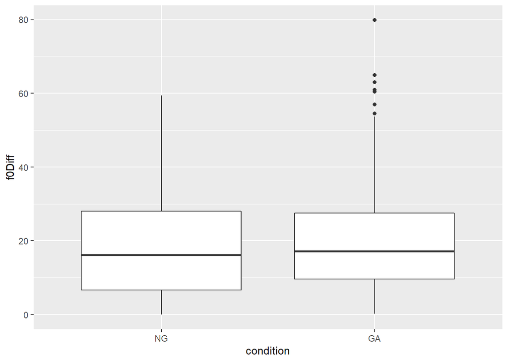

```r
ggplot(dac, aes(condition, f0Diff))+
  geom_boxplot()
```

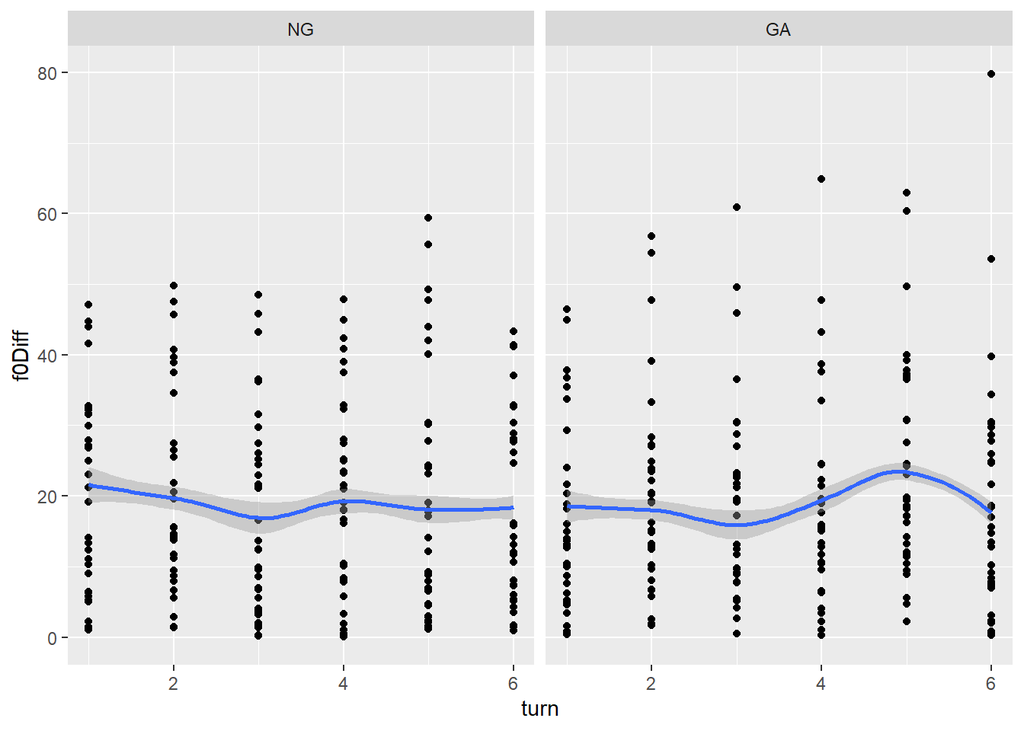

```r
ggplot(dac, aes(turn, f0Diff))+
  geom_point()+
  facet_wrap(~condition)+
  geom_smooth(method="loess")
```

The model with the f0 differences suggests and effect (opposite to what we found above), but if you see the graph above, you notice the effect isn’t linear, so we might need GAMMs or so for this to be accurate.

```r
summary(ft1 <- lmer(abs(f0Diff) ~ condition : turn + (1 + condition | speaker), dac))
```

```
## Linear mixed model fit by REML. t-tests use Satterthwaite's method [
## lmerModLmerTest]
## Formula: abs(f0Diff) ~ condition:turn + (1 + condition | speaker)
##    Data: dac
##
## REML criterion at convergence: 17015.5
##
## Scaled residuals:
##     Min      1Q  Median      3Q     Max
## -4.5059 -0.6138  0.0211  0.5746  5.4663
##
## Random effects:
##  Groups   Name        Variance Std.Dev. Corr
##  speaker  (Intercept) 170.51   13.058
##           conditionGA 298.19   17.268   -0.68
##  Residual              45.63    6.755
## Number of obs: 2508, groups:  speaker, 33
##
## Fixed effects:
##                   Estimate Std. Error        df t value Pr(>|t|)
## (Intercept)        19.8036     1.7050   34.3916  11.615 1.88e-13 ***
## conditionNG:turn   -0.5479     0.1204 2457.0873  -4.549 5.64e-06 ***
## conditionGA:turn    0.5291     0.1166 2461.7608   4.538 5.95e-06 ***
## ---
## Signif. codes:  0 '***' 0.001 '**' 0.01 '*' 0.05 '.' 0.1 ' ' 1
##
## Correlation of Fixed Effects:
##             (Intr) cndNG:
## cndtnNG:trn -0.135
## cndtnGA:trn -0.139  0.023
```

# f0 during baseline

### f0 mean

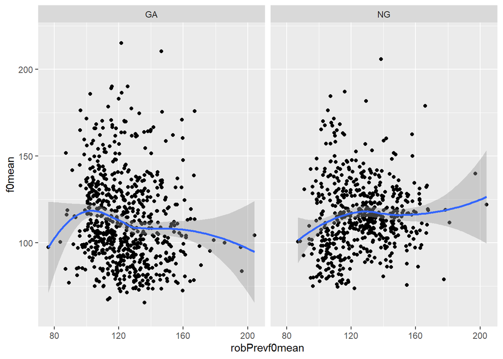

```r
ggplot(dab, aes(robPrevf0mean, f0mean))+
  geom_point()+
  facet_wrap(~condition)+
  geom_smooth(method="loess")
```

There is no lasting convergence effect in f0 mean.

```r
dab$condition <- relevel(dab$condition, ref="GA")
summary(fb1 <- lmer(f0mean ~  robf0meanc + (1 | speaker), dab))
```

```
## Linear mixed model fit by REML. t-tests use Satterthwaite's method [
## lmerModLmerTest]
## Formula: f0mean ~ robf0meanc + (1 | speaker)
##    Data: dab
##
## REML criterion at convergence: 10415.5
##
## Scaled residuals:
##     Min      1Q  Median      3Q     Max
## -5.0159 -0.5693 -0.1178  0.4543  5.6520
##
## Random effects:
##  Groups   Name        Variance Std.Dev.
##  speaker  (Intercept) 375.6    19.38
##  Residual             178.8    13.37
## Number of obs: 1280, groups:  speaker, 33
##
## Fixed effects:
##              Estimate Std. Error        df t value Pr(>|t|)
## (Intercept) 1.148e+02  3.395e+00 3.200e+01  33.803   <2e-16 ***
## robf0meanc  1.489e-02  2.590e-02 1.246e+03   0.575    0.566
## ---
## Signif. codes:  0 '***' 0.001 '**' 0.01 '*' 0.05 '.' 0.1 ' ' 1
##
## Correlation of Fixed Effects:
##            (Intr)
## robf0meanc 0.000
```

```r
summary(fb2 <- lmer(f0mean ~  robf0meanc  : condition + (1 + condition | speaker), dab))
```

```
## Linear mixed model fit by REML. t-tests use Satterthwaite's method [
## lmerModLmerTest]
## Formula: f0mean ~ robf0meanc:condition + (1 + condition | speaker)
##    Data: dab
##
## REML criterion at convergence: 10417.5
##
## Scaled residuals:
##     Min      1Q  Median      3Q     Max
## -5.0212 -0.5725 -0.1180  0.4563  5.6530
##
## Random effects:
##  Groups   Name        Variance Std.Dev. Corr
##  speaker  (Intercept) 484.1    22.00
##           conditionNG 263.3    16.23    -0.71
##  Residual             178.9    13.38
## Number of obs: 1280, groups:  speaker, 33
##
## Fixed effects:
##                         Estimate Std. Error        df t value Pr(>|t|)
## (Intercept)            1.151e+02  3.204e+00 2.864e+01  35.911   <2e-16 ***
## robf0meanc:conditionGA 3.833e-03  3.353e-02 1.245e+03   0.114    0.909
## robf0meanc:conditionNG 3.127e-02  4.081e-02 1.245e+03   0.766    0.444
## ---
## Signif. codes:  0 '***' 0.001 '**' 0.01 '*' 0.05 '.' 0.1 ' ' 1
##
## Correlation of Fixed Effects:
##             (Intr) rb0:GA
## rbf0mnc:cGA 0.000
## rbf0mnc:cNG 0.000  0.000
```

Also no “convergence” with mock data.

```r
summary(fbM <- lmer(f0mean ~ mockf0meanC + (1 | speaker), dab))
```

```
## Linear mixed model fit by REML. t-tests use Satterthwaite's method [
## lmerModLmerTest]
## Formula: f0mean ~ mockf0meanC + (1 | speaker)
##    Data: dab
##
## REML criterion at convergence: 11061.2
##
## Scaled residuals:
##     Min      1Q  Median      3Q     Max
## -4.6622 -0.5556 -0.0916  0.4466  5.0619
##
## Random effects:
##  Groups   Name        Variance Std.Dev.
##  speaker  (Intercept) 380.5    19.51
##  Residual             242.2    15.56
## Number of obs: 1312, groups:  speaker, 33
##
## Fixed effects:
##               Estimate Std. Error         df t value Pr(>|t|)
## (Intercept)  118.25547    3.42356   31.99996  34.542   <2e-16 ***
## mockf0meanC   -0.01513    0.02983 1278.00056  -0.507    0.612
## ---
## Signif. codes:  0 '***' 0.001 '**' 0.01 '*' 0.05 '.' 0.1 ' ' 1
##
## Correlation of Fixed Effects:
##             (Intr)
## mockf0meanC 0.000
```

```r
summary(fbM <- lmer(f0mean ~ mockf0meanC : condition + (1 | speaker), dab))
```

```
## Linear mixed model fit by REML. t-tests use Satterthwaite's method [
## lmerModLmerTest]
## Formula: f0mean ~ mockf0meanC:condition + (1 | speaker)
##    Data: dab
##
## REML criterion at convergence: 11062.1
##
## Scaled residuals:
##     Min      1Q  Median      3Q     Max
## -4.6385 -0.5538 -0.1079  0.4407  5.0303
##
## Random effects:
##  Groups   Name        Variance Std.Dev.
##  speaker  (Intercept) 380.5    19.51
##  Residual             241.8    15.55
## Number of obs: 1312, groups:  speaker, 33
##
## Fixed effects:
##                           Estimate Std. Error         df t value Pr(>|t|)
## (Intercept)              118.25550    3.42356   31.99996  34.542   <2e-16 ***
## mockf0meanC:conditionGA   -0.07508    0.04625 1277.00056  -1.623    0.105
## mockf0meanC:conditionNG    0.02747    0.03899 1277.00056   0.705    0.481
## ---
## Signif. codes:  0 '***' 0.001 '**' 0.01 '*' 0.05 '.' 0.1 ' ' 1
##
## Correlation of Fixed Effects:
##             (Intr) m0C:GA
## mckf0mnC:GA 0.000
## mckf0mnC:NG 0.000  0.000
```

### f0 SD

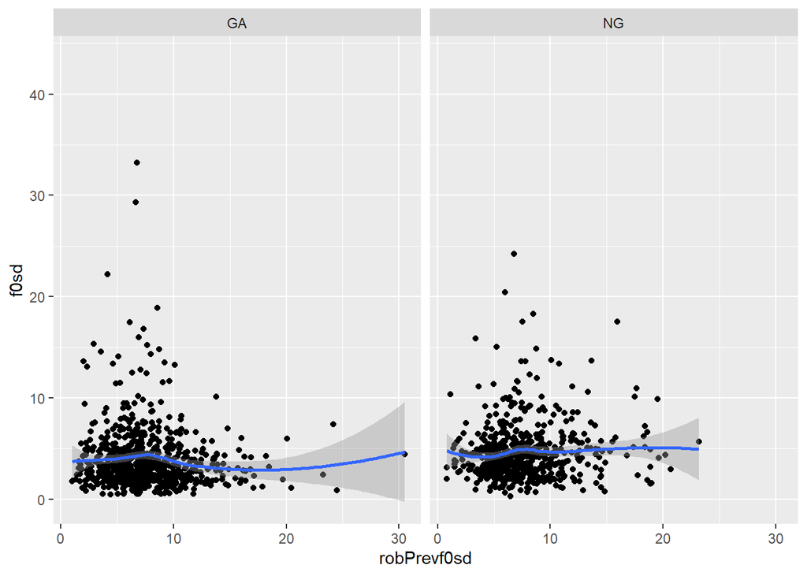

```r
ggplot(dab, aes(robPrevf0sd, f0sd))+
  geom_point()+
  facet_wrap(~condition)+
  geom_smooth(method="loess")
```

There is no lasting convergence effect in f0 SD.

```r
dab$condition <- relevel(dab$condition, ref="GA")
summary(fb1 <- lmer(f0mean ~  robf0sdc + (1 | speaker), dab))
```

```
## Linear mixed model fit by REML. t-tests use Satterthwaite's method [
## lmerModLmerTest]
## Formula: f0mean ~ robf0sdc + (1 | speaker)
##    Data: dab
##
## REML criterion at convergence: 10347.3
##
## Scaled residuals:
##     Min      1Q  Median      3Q     Max
## -4.9943 -0.5778 -0.1161  0.4421  5.6688
##
## Random effects:
##  Groups   Name        Variance Std.Dev.
##  speaker  (Intercept) 375.9    19.39
##  Residual             178.7    13.37
## Number of obs: 1272, groups:  speaker, 33
##
## Fixed effects:
##               Estimate Std. Error         df t value Pr(>|t|)
## (Intercept)  114.76244    3.39629   31.99843  33.791   <2e-16 ***
## robf0sdc      -0.06897    0.10794 1237.99871  -0.639    0.523
## ---
## Signif. codes:  0 '***' 0.001 '**' 0.01 '*' 0.05 '.' 0.1 ' ' 1
##
## Correlation of Fixed Effects:
##          (Intr)
## robf0sdc 0.000
```

```r
summary(fb2 <- lmer(f0mean ~  robf0sdc  : condition + (1  | speaker), dab))
```

```
## Linear mixed model fit by REML. t-tests use Satterthwaite's method [
## lmerModLmerTest]
## Formula: f0mean ~ robf0sdc:condition + (1 | speaker)
##    Data: dab
##
## REML criterion at convergence: 10347.1
##
## Scaled residuals:
##     Min      1Q  Median      3Q     Max
## -5.0380 -0.5705 -0.1062  0.4509  5.6927
##
## Random effects:
##  Groups   Name        Variance Std.Dev.
##  speaker  (Intercept) 375.9    19.39
##  Residual             178.6    13.36
## Number of obs: 1272, groups:  speaker, 33
##
## Fixed effects:
##                        Estimate Std. Error         df t value Pr(>|t|)
## (Intercept)           114.76244    3.39629   31.99840  33.791   <2e-16 ***
## robf0sdc:conditionGA    0.04946    0.14651 1236.99872   0.338    0.736
## robf0sdc:conditionNG   -0.20946    0.15957 1236.99872  -1.313    0.190
## ---
## Signif. codes:  0 '***' 0.001 '**' 0.01 '*' 0.05 '.' 0.1 ' ' 1
##
## Correlation of Fixed Effects:
##             (Intr) rb0:GA
## rbf0sdc:cGA 0.000
## rbf0sdc:cNG 0.000  0.000
```

Also no “convergence” with mock data.

```r
summary(fbM <- lmer(f0mean ~ mockf0sdC + (1 | speaker), dab))
```

```
## Linear mixed model fit by REML. t-tests use Satterthwaite's method [
## lmerModLmerTest]
## Formula: f0mean ~ mockf0sdC + (1 | speaker)
##    Data: dab
##
## REML criterion at convergence: 10988.4
##
## Scaled residuals:
##     Min      1Q  Median      3Q     Max
## -4.6127 -0.5573 -0.0978  0.4400  5.0753
##
## Random effects:
##  Groups   Name        Variance Std.Dev.
##  speaker  (Intercept) 380.0    19.49
##  Residual             243.2    15.59
## Number of obs: 1303, groups:  speaker, 33
##
## Fixed effects:
##              Estimate Std. Error        df t value Pr(>|t|)
## (Intercept)  118.2770     3.4217   32.0041  34.567   <2e-16 ***
## mockf0sdC     -0.0884     0.1242 1269.0047  -0.712    0.477
## ---
## Signif. codes:  0 '***' 0.001 '**' 0.01 '*' 0.05 '.' 0.1 ' ' 1
##
## Correlation of Fixed Effects:
##           (Intr)
## mockf0sdC 0.000
```

```r
summary(fbM <- lmer(f0mean ~ mockf0sdC : condition + (1 | speaker), dab))
```

```
## Linear mixed model fit by REML. t-tests use Satterthwaite's method [
## lmerModLmerTest]
## Formula: f0mean ~ mockf0sdC:condition + (1 | speaker)
##    Data: dab
##
## REML criterion at convergence: 10988.8
##
## Scaled residuals:
##     Min      1Q  Median      3Q     Max
## -4.6432 -0.5547 -0.0965  0.4435  5.0582
##
## Random effects:
##  Groups   Name        Variance Std.Dev.
##  speaker  (Intercept) 380.0    19.49
##  Residual             243.3    15.60
## Number of obs: 1303, groups:  speaker, 33
##
## Fixed effects:
##                         Estimate Std. Error         df t value Pr(>|t|)
## (Intercept)            1.183e+02  3.422e+00  3.200e+01  34.567   <2e-16 ***
## mockf0sdC:conditionGA -1.944e-01  1.824e-01  1.268e+03  -1.066    0.287
## mockf0sdC:conditionNG  3.344e-03  1.697e-01  1.268e+03   0.020    0.984
## ---
## Signif. codes:  0 '***' 0.001 '**' 0.01 '*' 0.05 '.' 0.1 ' ' 1
##
## Correlation of Fixed Effects:
##             (Intr) m0C:GA
## mckf0sdC:GA 0.000
## mckf0sdC:NG 0.000  0.000
```

# Questionnaire ratings and condition

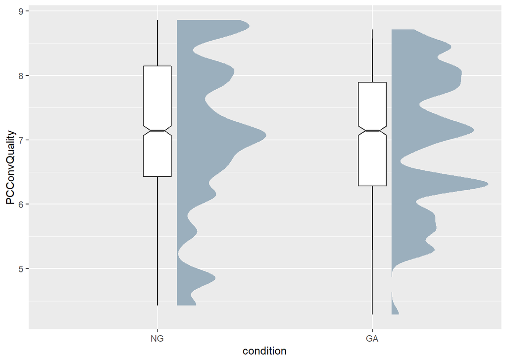

```r
ggplot(dac, aes(condition, PCConvQuality))+
  stat_halfeye(adjust = .5,  width = .5, justification = -.2, .width = c(.5, .95), fill="#9bafbd")+
  geom_boxplot(width=.13, notch = TRUE)
```

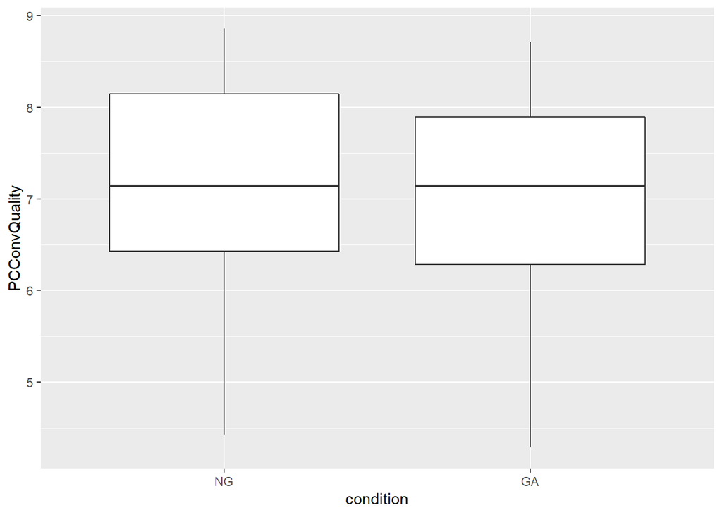

```r
ggplot(dac, aes(condition, PCConvQuality))+
  geom_boxplot()
```

I doubt the robustness of this result.

(Model’s residuals: homoskedastic (good) but far from normally distributed.)

```r
summary(cq1 <- lm(PCConvQuality ~ condition, dac %>% filter(!duplicated(speaker))))
```

```
##
## Call:
## lm(formula = PCConvQuality ~ condition, data = dac %>% filter(!duplicated(speaker)))
##
## Residuals:
##     Min      1Q  Median      3Q     Max
## -2.7321 -0.5630  0.0084  1.0084  1.6964
##
## Coefficients:
##             Estimate Std. Error t value Pr(>|t|)
## (Intercept)   7.1607     0.3142  22.793   <2e-16 ***
## conditionGA  -0.3120     0.4377  -0.713    0.481
## ---
## Signif. codes:  0 '***' 0.001 '**' 0.01 '*' 0.05 '.' 0.1 ' ' 1
##
## Residual standard error: 1.257 on 31 degrees of freedom
## Multiple R-squared:  0.01612,    Adjusted R-squared:  -0.01561
## F-statistic: 0.508 on 1 and 31 DF,  p-value: 0.4813
```

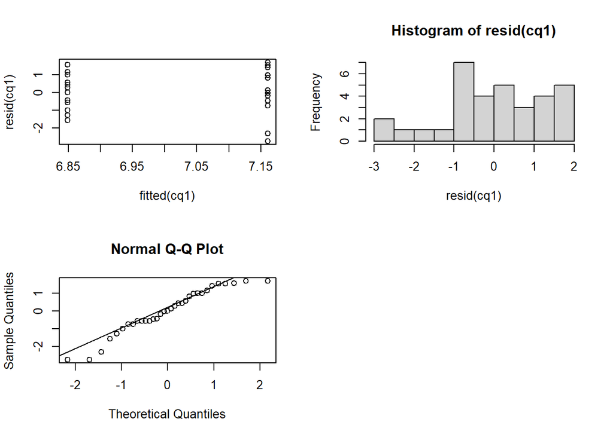

```r
par(mfrow=c(2,2))
plot(fitted(cq1), resid(cq1))
hist(resid(cq1))
qqnorm(resid(cq1));qqline(resid(cq1))
```

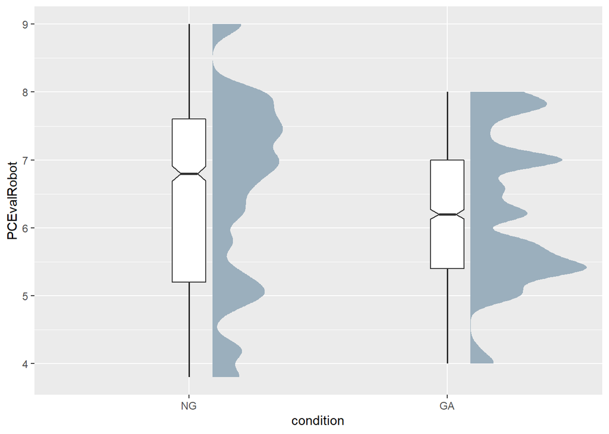

```r
ggplot(dac, aes(condition, PCEvalRobot))+
  stat_halfeye(adjust = .5,  width = .5, justification = -.2, .width = c(.5, .95), fill="#9bafbd")+
  geom_boxplot(width=.13, notch = TRUE)
```

(Model’s residuals: also homoskedastic (good), and distribution isn’t very normal but better than the conversational quality model above.)

```r
summary(rq1 <- lm(PCEvalRobot ~ condition, dac %>% filter(!duplicated(speaker))))
```

```
##
## Call:
## lm(formula = PCEvalRobot ~ condition, data = dac %>% filter(!duplicated(speaker)))
##
## Residuals:
##     Min      1Q  Median      3Q     Max
## -2.3875 -0.8941  0.0125  1.0125  2.4125
##
## Coefficients:
##             Estimate Std. Error t value Pr(>|t|)
## (Intercept)   6.5875     0.3099  21.254   <2e-16 ***
## conditionGA  -0.2934     0.4318  -0.679    0.502
## ---
## Signif. codes:  0 '***' 0.001 '**' 0.01 '*' 0.05 '.' 0.1 ' ' 1
##
## Residual standard error: 1.24 on 31 degrees of freedom
## Multiple R-squared:  0.01467,    Adjusted R-squared:  -0.01711
## F-statistic: 0.4616 on 1 and 31 DF,  p-value: 0.5019
```

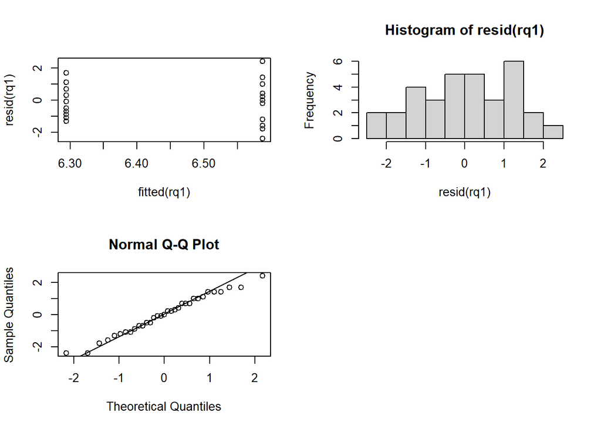

```r
par(mfrow=c(2,2))
plot(fitted(rq1), resid(rq1))
hist(resid(rq1))
qqnorm(resid(rq1));qqline(resid(rq1))
```